# Name: Sergiy Goloviatinski

- Please answer the question in the same order as in the assignment and use the same question numbers;
- Don't answer the questions in the code comments. Use the text cells in your notebook;
- Remove clutter such as unused code lines instead of turning them into comments;
- Make sure the right execution order of the notebook cells is from top to bottom. A TA should be able to reproduce your results by simply clicking "Run All" without having to guess which cells should be executed first.

# Assignment 1 ATML 2020

Download the dataset files from ILIAS and put them in the same folder as this notebook.

```python
import numpy as np
images = np.load('data/imgs_train.npy')
labels = np.load('data/labels_train.npy')

test_images = np.load('data/imgs_test.npy')
test_labels = np.load('data/labels_test.npy')
```

## Task 1. Prepare data for training and model selection

### Load the data and visualize an image for each class.

```
Class 0
```

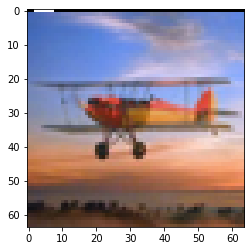

```
Class 1
```

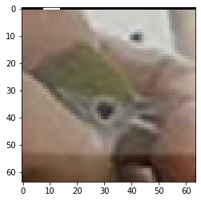

```
Class 2
```

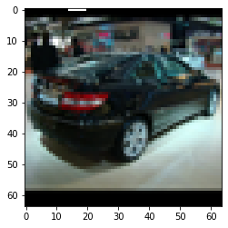

```
Class 3
```

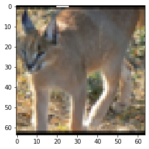

```
Class 4
```

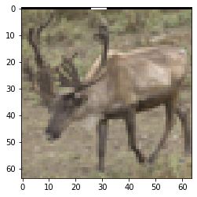

```
Class 5
```

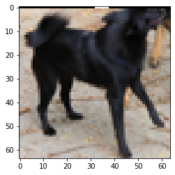

```
Class 6
```

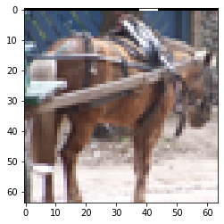

```
Class 7
```

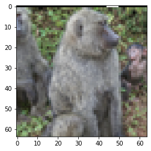

```
Class 8
```

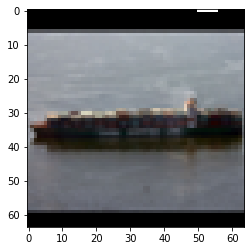

```
Class 9
```

[figure not shown]

```python
import random

class_indexes={}
examples_per_class=1

for i in range(0,10):
    class_indexes[i]=[x[0] for x in random.sample(list(np.argwhere(np.array(labels)==i)),examples_per_class)]

%matplotlib inline
import matplotlib.pyplot as plt

for i_class in class_indexes.keys():
    print(f'Class {i_class}')
    for i in class_indexes[i_class]:
        plt.imshow(images[i])
        plt.show()
```

### Set aside 90% of training data for training, and the remaining 10% for validation. Make sure the label distribution is the same in training and validation set.

```python
total=len(labels)
original_label_distribution={}
for i in range(10):
    original_label_distribution[i]=np.count_nonzero(labels==i)


print(f'Original label distribution:')
for label,distribution in original_label_distribution.items():
    print(f'\tClass {label}: {distribution} ({distribution/total*100}%)')

train_set_labels=np.array([])
validation_set_labels=np.array([])

train_set_indexes=np.array([],dtype=int)
validation_set_indexes=np.array([],dtype=int)

for i in range(10):
    train_set_labels_class_i=[x[0] for x in random.sample(list(np.argwhere(np.array(labels)==i)),int(original_label_distribution[i]*0.9))]
    train_set_indexes=np.append(train_set_indexes,train_set_labels_class_i)

    validation_set_labels_class_i=np.setdiff1d([x[0] for x in np.argwhere(np.array(labels)==i)],train_set_labels_class_i)
    validation_set_indexes=np.append(validation_set_indexes,validation_set_labels_class_i)

    train_set_labels=np.append(train_set_labels,[i]*len(train_set_labels_class_i))
    validation_set_labels=np.append(validation_set_labels,[i]*len(validation_set_labels_class_i))


train_set_=np.take(images,train_set_indexes,axis=0)
validation_set_=np.take(images,validation_set_indexes,axis=0)

total_train=len(train_set_labels)
total_validation=len(validation_set_labels)
train_label_distribution={}
validation_label_distribution={}

for i in range(10):
    train_label_distribution[i]=np.count_nonzero(train_set_labels==i)
    validation_label_distribution[i]=np.count_nonzero(validation_set_labels==i)

print(f'\n\nTrain set label distribution:')
for label,distribution in train_label_distribution.items():
    print(f'\tClass {label}: {distribution} ({distribution/total_train*100}%)')

print(f'\nValidation set label distribution:')
for label,distribution in validation_label_distribution.items():
    print(f'\tClass {label}: {distribution} ({distribution/total_validation*100}%)')
```

```
Original label distribution:
	Class 0: 500 (10.0%)
	Class 1: 500 (10.0%)
	Class 2: 500 (10.0%)
	Class 3: 500 (10.0%)
	Class 4: 500 (10.0%)
	Class 5: 500 (10.0%)
	Class 6: 500 (10.0%)
	Class 7: 500 (10.0%)
	Class 8: 500 (10.0%)
	Class 9: 500 (10.0%)


Train set label distribution:
	Class 0: 450 (10.0%)
	Class 1: 450 (10.0%)
	Class 2: 450 (10.0%)
	Class 3: 450 (10.0%)
	Class 4: 450 (10.0%)
	Class 5: 450 (10.0%)
	Class 6: 450 (10.0%)
	Class 7: 450 (10.0%)
	Class 8: 450 (10.0%)
	Class 9: 450 (10.0%)

Validation set label distribution:
	Class 0: 50 (10.0%)
	Class 1: 50 (10.0%)
	Class 2: 50 (10.0%)
	Class 3: 50 (10.0%)
	Class 4: 50 (10.0%)
	Class 5: 50 (10.0%)
	Class 6: 50 (10.0%)
	Class 7: 50 (10.0%)
	Class 8: 50 (10.0%)
	Class 9: 50 (10.0%)
```

### Implement a Dataset class that extends Pytorch’s Dataset class. Create dataset objects and dataloaders for training and validation datasets. Make sure you normalize your data.

```python
import torch
from torchvision.transforms import ToTensor, Normalize, Compose
from torch.utils.data import DataLoader

device = torch.device('cuda' if torch.cuda.is_available() else 'cpu')

class NormalizedDatasetWrapper(torch.utils.data.Dataset):
    '''Loads all data into memory; good for small models and small datasets. Normalizes the data.'''
    def __init__(self, data, labels):

        transforms = Compose([ToTensor(), # Converts to Tensor, scales to [0, 1] float (from [0, 255] int)
                    Normalize(mean=(0.5, 0.5, 0.5,), std=(0.5, 0.5, 0.5)), # scales to [-1.0, 1.0]
                    ])

        self.data = []
        self.labels=[]

        for label in labels:
            self.labels.append(int(label))

        for sample in data:
            self.data.append(transforms(sample))

        self.n = len(self.data)

    def __getitem__(self, ind):
        return self.data[ind],self.labels[ind]

    def __len__(self):
        return self.n

train_set = NormalizedDatasetWrapper(train_set_,train_set_labels)
validation_set = NormalizedDatasetWrapper(validation_set_,validation_set_labels)

batch_size = 32

train_dataloader = DataLoader(train_set, batch_size=batch_size, shuffle=True, num_workers=4) #num_workers = n - how many threads in background for efficient loading
val_dataloader = DataLoader(validation_set, batch_size=batch_size, shuffle=False, num_workers=4)
```

## Task 2. Train a linear classification model

### Implement a linear classification model that will predict the label of a given image. Implement the training of the model with PyTorch’s optimizer and a loss function appropriate for the task.

```python
import torch.nn as nn
from tqdm.notebook import tqdm

class LinearModel(nn.Module):

    def __init__(self, input_dim):
        super(LinearModel, self).__init__()
        self.fc = nn.Linear(input_dim, 10, bias=True) # outputs 10 values - score for each class

    def forward(self, input):
        out = input.view(input.size(0), -1) # convert batch_size x 3 x imH x imW to batch_size x (3*imH*imW)
        out = self.fc(out) # Applies out = input * A + b. A, b are parameters of nn.Linear that we want to learn
        return out


# Initialize loss function and parameters
loss_fn = nn.CrossEntropyLoss()

def train_epoch(model, train_dataloader, optimizer, loss_fn):
    losses = []
    correct_predictions = 0

    # Iterate mini batches over training dataset
    for images, labels in tqdm(train_dataloader):
        images = images.to(device)
        labels = labels.to(device)
        # Run predictions
        output = model(images)
        # Set gradients to zero
        optimizer.zero_grad()
        # Compute loss
        loss = loss_fn(output, labels)
        # Backpropagate (compute gradients)
        loss.backward()
        # Make an optimization step (update parameters)
        optimizer.step()
        # Log metrics
        losses.append(loss.item())
        predicted_labels = output.argmax(dim=1)
        correct_predictions += (predicted_labels == labels).sum().item()
    # Return loss values for each iteration and accuracy
    mean_loss = np.array(losses).mean()
    accuracy = 100.0 * correct_predictions / len(train_dataloader.dataset)
    return mean_loss, accuracy

def evaluate(model, dataloader, loss_fn):
    losses = []
    correct_predictions = 0
    # Iterate mini batches over validation dataset
    with torch.no_grad():
        for images, labels in dataloader:
            images = images.to(device)
            labels = labels.to(device)
            # Run predictions
            output = model(images)
            # Compute loss
            loss = loss_fn(output, labels)
            # Save metrics
            losses.append(loss.item())
            predicted_labels = output.argmax(dim=1)
            correct_predictions += (predicted_labels == labels).sum().item()
    # Return mean loss and accuracy
    mean_loss = np.array(losses).mean()
    accuracy = 100.0 * correct_predictions / len(dataloader.dataset)
    return mean_loss, accuracy

def train(model, train_dataloader, val_dataloader, optimizer, n_epochs, loss_function):
    # We will monitor loss functions as the training progresses
    train_losses = []
    val_losses = []
    train_accuracies = []
    val_accuracies = []

    # Run training for n_epochs
    for epoch in range(n_epochs):
        model.train()
        train_loss, train_accuracy = train_epoch(model, train_dataloader, optimizer, loss_fn)
        model.eval()
        val_loss, val_accuracy = evaluate(model, val_dataloader, loss_fn)
        train_losses.append(train_loss)
        val_losses.append(val_loss)
        train_accuracies.append(train_accuracy)
        val_accuracies.append(val_accuracy)
        print('Epoch {}/{}: train_loss: {:.4f}, train_accuracy: {:.4f}, val_loss: {:.4f}, val_accuracy: {:.4f}'.format(epoch+1, n_epochs,
                                                                                                      train_losses[-1],
                                                                                                      train_accuracies[-1],
                                                                                                      val_losses[-1],
                                                                                                      val_accuracies[-1]))
    return train_losses, val_losses, train_accuracies, val_accuracies
```

### Train at least 3 models using different (reasonable) learning rates, train for at least 10 epochs. For each model evaluate on validation dataset after every epoch. Plot training and validation loss and accuracy per epoch. Select the best model based on the results on the validation set

```python
learning_rates=[0.001,0.005,0.01]

models={}
optimizers={}

for learning_rate in learning_rates:
    models[learning_rate]=LinearModel(images.shape[1]*images.shape[2]*images.shape[3]).to(device)
    optimizers[learning_rate]=torch.optim.SGD(models[learning_rate].parameters(), lr=learning_rate)


n_epochs = 25

train_losses={}
val_losses={}
train_acc={}
val_acc={}

for learning_rate in learning_rates:
    print(f'\nTraining model with lr = {learning_rate}')
    train_losses_i, val_losses_i, train_acc_i, val_acc_i = train(models[learning_rate], train_dataloader, val_dataloader, optimizers[learning_rate], n_epochs=n_epochs, loss_function=loss_fn)
    train_losses[learning_rate]=train_losses_i
    val_losses[learning_rate]=val_losses_i
    train_acc[learning_rate]=train_acc_i
    val_acc[learning_rate]=val_acc_i
```

```
Training model with lr = 0.001
```

```
Training model with lr = 0.005
```

```
Training model with lr = 0.01
```

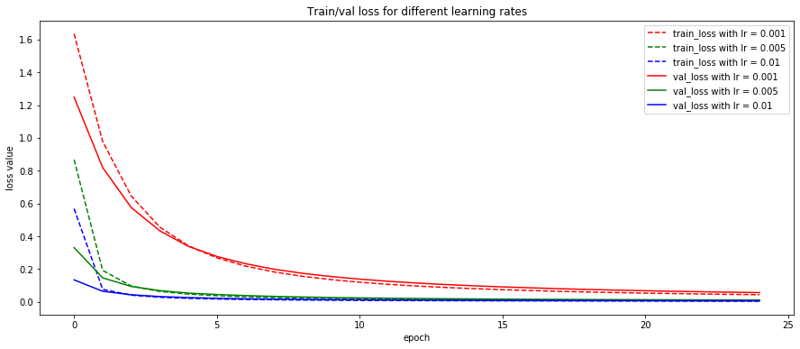

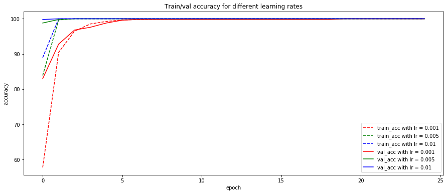

```python
def plot(n_epochs, train_losses, val_losses, train_accuracies, val_accuracies):
    plt.figure(figsize=(15,6))

    legend_loss=[]

    colors=['r','g','b']

    i=0
    for learning_rate,train_loss in train_losses.items():
        plt.plot(np.arange(n_epochs), train_loss,f'{colors[i]}--')
        legend_loss.append(f'train_loss with lr = {learning_rate}')
        i+=1

    i=0
    for learning_rate,val_loss in val_losses.items():
        plt.plot(np.arange(n_epochs), val_loss,colors[i])
        legend_loss.append(f'val_loss with lr = {learning_rate}')
        i+=1

    plt.legend(legend_loss)

    plt.xlabel('epoch')
    plt.ylabel('loss value')
    plt.title('Train/val loss for different learning rates');

    plt.figure(figsize=(15,6))

    legend_acc=[]

    i=0
    for learning_rate,train_acc in train_accuracies.items():
        plt.plot(np.arange(n_epochs), train_acc,f'{colors[i]}--')
        legend_acc.append(f'train_acc with lr = {learning_rate}')
        i+=1

    i=0
    for learning_rate,val_acc in val_accuracies.items():
        plt.plot(np.arange(n_epochs), val_acc,colors[i])
        legend_acc.append(f'val_acc with lr = {learning_rate}')
        i+=1

    plt.legend(legend_acc)
    plt.xlabel('epoch')
    plt.ylabel('accuracy')
    plt.title('Train/val accuracy for different learning rates');

plot(n_epochs, train_losses, val_losses, train_acc, val_acc)
```

### Report learning rate for the selected model as well as loss and accuracy on training and validation sets.

```python
print('Selected model with learning rate = 0.01')
print(f'\tTraining loss: {train_losses[0.01][-1]}')
print(f'\tValidation loss: {val_losses[0.01][-1]}')
print(f'\tTraining accuracy: {train_acc[0.01][-1]}')
print(f'\tValidation accuracy: {val_acc[0.01][-1]}')
```

```
Selected model with learning rate = 0.01
	Training loss: 0.003559660508317199
	Validation loss: 0.005468761941301636
	Training accuracy: 100.0
	Validation accuracy: 100.0
```

```python
for lr in train_losses.keys():
    print(f'Losses and accuracies for model with learning rate = {lr}')
    print(f'\tTraining loss: {train_losses[lr][-1]}')
    print(f'\tValidation loss: {val_losses[lr][-1]}')
    print(f'\tTraining accuracy: {train_acc[lr][-1]}')
    print(f'\tValidation accuracy: {val_acc[lr][-1]}')
```

```
Losses and accuracies for model with learning rate = 0.001
	Training loss: 0.04285621433023443
	Validation loss: 0.05584262823686004
	Training accuracy: 100.0
	Validation accuracy: 100.0
Losses and accuracies for model with learning rate = 0.005
	Training loss: 0.007330198006057147
	Validation loss: 0.010604917188175023
	Training accuracy: 100.0
	Validation accuracy: 100.0
Losses and accuracies for model with learning rate = 0.01
	Training loss: 0.003559660508317199
	Validation loss: 0.005468761941301636
	Training accuracy: 100.0
	Validation accuracy: 100.0
```

#### Report below:

**REPORT** *plots, validation losses and accuracies for different learning rates, learning rate for the selected best performing model*

[figure not shown]

- Validation losses and accuracies for different learning rates:

  ```
  Losses and accuracies for model with learning rate = 0.001
    Training loss: 0.04285621433023443
    Validation loss: 0.05584262823686004
    Training accuracy: 100.0
    Validation accuracy: 100.0
  Losses and accuracies for model with learning rate = 0.005
    Training loss: 0.007330198006057147
    Validation loss: 0.010604917188175023
    Training accuracy: 100.0
    Validation accuracy: 100.0
  Losses and accuracies for model with learning rate = 0.01
    Training loss: 0.003559660508317199
    Validation loss: 0.005468761941301636
    Training accuracy: 100.0
    Validation accuracy: 100.0
  ```

- Learning rate for the selected best performing model: 0.01

## Task 3. Evaluate on the test set

### Evaluate your selected model on the test set. How is the accuracy different from the training and validation set? What is this a sign of?

```
Test average loss: 5.1616, accuracy: 10.000
```

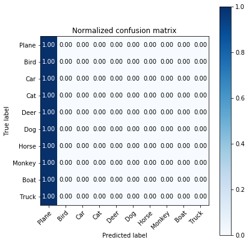

```python
from sklearn.metrics import confusion_matrix
from sklearn.utils.multiclass import unique_labels

def plot_confusion_matrix(y_true, y_pred, classes,
                          normalize=False,
                          title=None,
                          cmap=plt.cm.Blues):
    """
    This function prints and plots the confusion matrix.
    Normalization can be applied by setting `normalize=True`.
    """
    if not title:
        if normalize:
            title = 'Normalized confusion matrix'
        else:
            title = 'Confusion matrix, without normalization'

    # Compute confusion matrix
    cm = confusion_matrix(y_true, y_pred)
    # Only use the labels that appear in the data
    classes = classes[unique_labels(y_true, y_pred)]
    if normalize:
        cm = cm.astype('float') / cm.sum(axis=1)[:, np.newaxis]

    fig, ax = plt.subplots(figsize=(6,6))
    im = ax.imshow(cm, interpolation='nearest', cmap=cmap)
    ax.figure.colorbar(im, ax=ax)
    # We want to show all ticks...
    ax.set(xticks=np.arange(cm.shape[1]),
           yticks=np.arange(cm.shape[0]),
           # ... and label them with the respective list entries
           xticklabels=classes, yticklabels=classes,
           title=title,
           ylabel='True label',
           xlabel='Predicted label')

    # Rotate the tick labels and set their alignment.
    plt.setp(ax.get_xticklabels(), rotation=45, ha="right",
             rotation_mode="anchor")

    # Loop over data dimensions and create text annotations.
    fmt = '.2f' if normalize else 'd'
    thresh = cm.max() / 2.
    for i in range(cm.shape[0]):
        for j in range(cm.shape[1]):
            ax.text(j, i, format(cm[i, j], fmt),
                    ha="center", va="center",
                    color="white" if cm[i, j] > thresh else "black")
    fig.tight_layout()
    return ax

def test(model,dataloader):
    model.eval()
    test_loss = 0
    n_correct = 0
    y_true=np.array([],dtype=int)
    y_pred=np.array([],dtype=int)
    with torch.no_grad():
        for images, labels in dataloader:
            images = images.to(device)
            labels = labels.to(device)
            output = model(images)
            loss = loss_fn(output, labels)
            test_loss += loss.item()
            for y in output.argmax(1).numpy():
                y_pred=np.append(y_pred,y)
            for y in labels.numpy():
                y_true=np.append(y_true,y)
            n_correct += torch.sum(output.argmax(1) == labels).item()

    average_loss = test_loss / len(dataloader)
    accuracy = 100.0 * n_correct / len(dataloader.dataset)
    print('Test average loss: {:.4f}, accuracy: {:.3f}'.format(average_loss, accuracy))
    plot_confusion_matrix(y_true,y_pred,np.asarray("Plane Bird Car Cat Deer Dog Horse Monkey Boat Truck".split()),normalize=True)

test_set = NormalizedDatasetWrapper(test_images,test_labels)
test_dataloader = DataLoader(test_set, batch_size=batch_size, shuffle=True, num_workers=4)
test(models[0.01],test_dataloader)
```

```python
total_test=len(test_labels)
test_label_distribution={}

for i in range(10):
    test_label_distribution[i]=np.count_nonzero(test_labels==i)

print(f'\n\nTrain set label distribution:')
for label,distribution in test_label_distribution.items():
    print(f'\tClass {label}: {distribution} ({distribution/total_test*100}%)')
```

```
Train set label distribution:
	Class 0: 800 (10.0%)
	Class 1: 800 (10.0%)
	Class 2: 800 (10.0%)
	Class 3: 800 (10.0%)
	Class 4: 800 (10.0%)
	Class 5: 800 (10.0%)
	Class 6: 800 (10.0%)
	Class 7: 800 (10.0%)
	Class 8: 800 (10.0%)
	Class 9: 800 (10.0%)
```

The model predicts all samples from the test set as class 0, therefore it has 10% accuracy because 10% of the test set are from the class 0, this is a sign of overfitting on the train data.

### Visualize a few images from your test dataset. Are there any differences between train and test images?

```
Example from class 7 in train set:
```

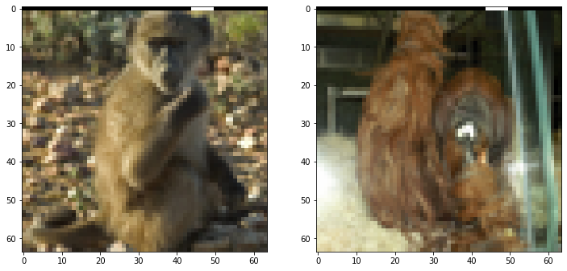

```
Example from class 7 in test set:
```

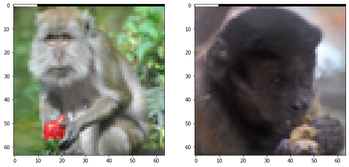

```
Example from class 5 in train set:
```

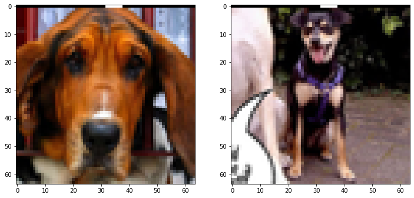

```
Example from class 5 in test set:
```

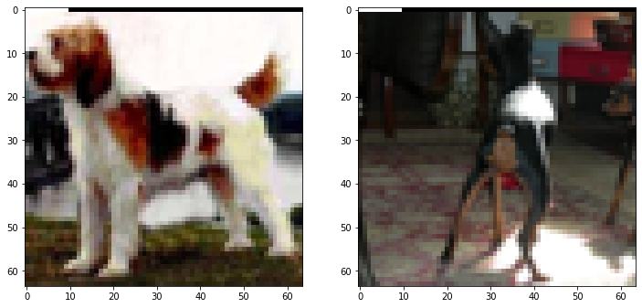

```
Example from class 1 in train set:
```

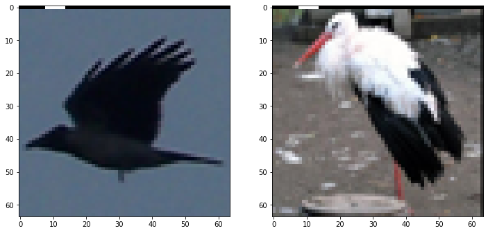

```
Example from class 1 in test set:
```

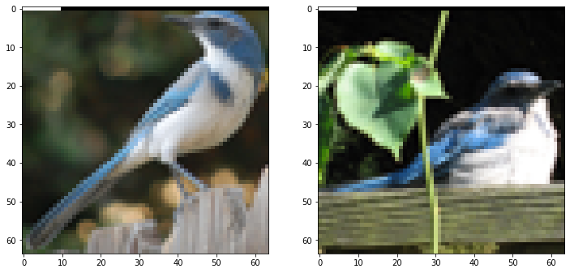

```python
for i in np.random.choice(10, 3,replace=False):
    print(f'Example from class {i} in train set:')

    f, axarr = plt.subplots(1,2,figsize=(12,12))

    for x in range(2):
        axarr[x].imshow(images[random.sample(list(np.argwhere(np.array(labels)==i)),1)[0][0]])

    plt.show()

    print(f'Example from class {i} in test set:')

    f, axarr = plt.subplots(1,2,figsize=(12,12))

    for x in range(2):
        axarr[x].imshow(test_images[random.sample(list(np.argwhere(np.array(test_labels)==i)),1)[0][0]])

    plt.show()
```

The top line of pixels in each image indicates visually to which class belongs the image, and their position is not the same in the train and test set (e.g. in the train set, all images of the class 0 have a white line on the left side of the image, whereas in the test set all the classes have this white line at the same position as the class 0 in the train set)

This explains why the accuracy is at 10% for the test set: the model predicts always class 0, and because class 0 is 10% of the test set, it has 10% of accuracy.

### Visualize the weights of your linear model. What did the model learn? Why does it fail on test images?

```
Class 0:
```

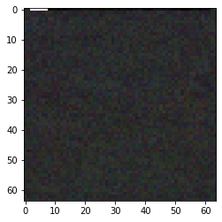

```
Class 1:
```

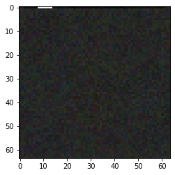

```
Class 2:
```

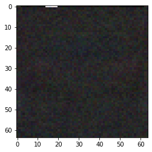

```
Class 3:
```

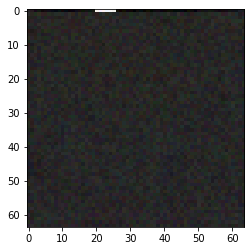

```
Class 4:
```

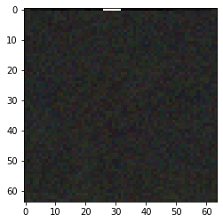

```
Class 5:
```

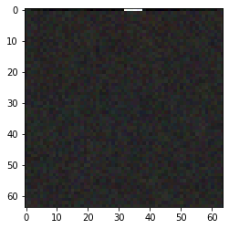

```
Class 6:
```

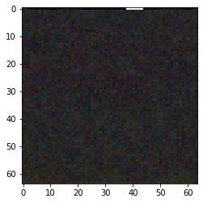

```
Class 7:
```

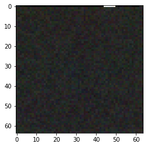

```
Class 8:
```

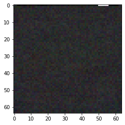

```
Class 9:
```

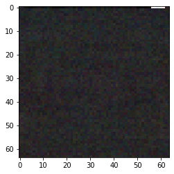

```python
# Visualize learned weights
class_weights = []
shape=len(models[0.01].fc.weight[0])
for i in range(10):
    class_weight = models[0.01].fc.weight[i].view((3,64,64)).detach().cpu().numpy()
    class_weight = class_weight - class_weight.min()
    class_weight = class_weight / class_weight.max() # it's in [0; 1] now
    class_weights.append(class_weight)

for i in range(10):
    print(f'Class {i}:')
    plt.figure()
    plt.imshow(class_weights[i].transpose(1,2,0), cmap='gray')
    plt.show()
```

#### Report below:

**REPORT**: Compare validation and test acccuracy. Comment on differences.  
How are test images different from train images?  
Visualize weights of your best linear model. What did the model learn? How does it distinguish images? Why does it fail on test images?

- Compare validation and test acccuracy. Comment on differences.
  - Validation accuracy: 100%, test accuracy: 10%. It means that our model cannot generalize and is overfitted.
- How are test images different from train images?
  - The first line of the train images represents the class to which the image belongs, whereas in the test set this first line is the same for all the classes.
- Visualize weights of your best linear model. What did the model learn? How does it distinguish images? Why does it fail on test images?
  - The model learned to discriminate between classes only by taking in account the first line of the images (each class in the train set has the white part of the line in a different position), it fails on test images because this line is the same between all the classes (like class 0 in train set) therefore the model predicts all the test images as class 0, and because class 0 is 10% of the test set, the accuracy is 10%

## Task 4. Fix the observed problem

### Based on observations from the previous point, propose a way to fix your solution; you can still only use a simple linear model.

I crop out the first line of the train+test images

```python
class CropFirstLineDatasetWrapper(torch.utils.data.Dataset):
    '''Loads all data into memory; good for small models and small datasets. Normalizes the data + removes the first line of each image.'''
    def __init__(self, data, labels):

        transforms = Compose([ToTensor(), # Converts to Tensor, scales to [0, 1] float (from [0, 255] int)
                    Normalize(mean=(0.5, 0.5, 0.5,), std=(0.5, 0.5, 0.5)), # scales to [-1.0, 1.0]
                    ])

        self.data = []
        self.labels=[]

        for label in labels:
            self.labels.append(int(label))

        for sample in data:
            self.data.append(transforms(sample[1:,:]))

        self.n = len(self.data)

    def __getitem__(self, ind):
        return self.data[ind],self.labels[ind]

    def __len__(self):
        return self.n

test_set = CropFirstLineDatasetWrapper(test_images,test_labels)
train_set = CropFirstLineDatasetWrapper(train_set_,train_set_labels)
validation_set = CropFirstLineDatasetWrapper(validation_set_,validation_set_labels)

train_dataloader = DataLoader(train_set, batch_size=batch_size, shuffle=True, num_workers=4) #num_workers = n - how many threads in background for efficient loading
val_dataloader = DataLoader(validation_set, batch_size=batch_size, shuffle=False, num_workers=4)
test_dataloader = DataLoader(test_set, batch_size=batch_size, shuffle=True, num_workers=4)
```

### Repeat training and evaluation from points 2 and 3 with your improvements. Report accuracy on training, validation and test sets.

```python
learning_rates=[0.001,0.005,0.01]

models={}
optimizers={}

for learning_rate in learning_rates:
    models[learning_rate]=LinearModel((images.shape[1]-1)*images.shape[2]*images.shape[3]).to(device)
    optimizers[learning_rate]=torch.optim.SGD(models[learning_rate].parameters(), lr=learning_rate)


n_epochs = 25

train_losses={}
val_losses={}
train_acc={}
val_acc={}

for learning_rate in learning_rates:
    print(f'\nTraining model with lr = {learning_rate}')
    train_losses_i, val_losses_i, train_acc_i, val_acc_i = train(models[learning_rate], train_dataloader, val_dataloader, optimizers[learning_rate], n_epochs=n_epochs, loss_function=loss_fn)
    train_losses[learning_rate]=train_losses_i
    val_losses[learning_rate]=val_losses_i
    train_acc[learning_rate]=train_acc_i
    val_acc[learning_rate]=val_acc_i
```

```
Training model with lr = 0.001
```

```
Training model with lr = 0.005
```

```
Training model with lr = 0.01
```

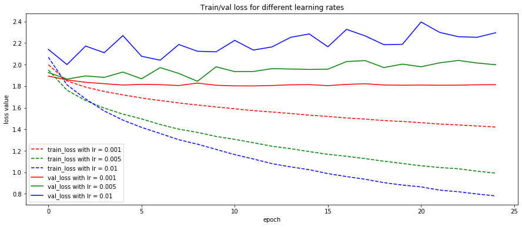

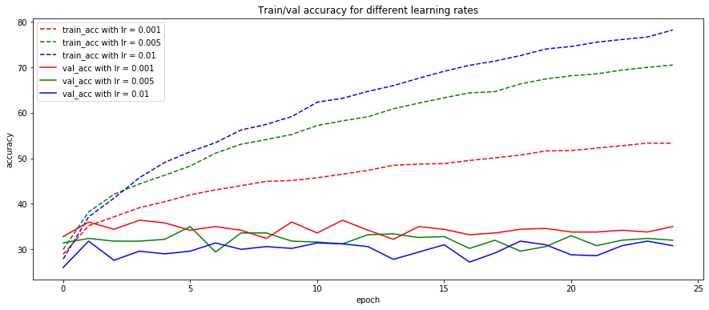

```python
plot(n_epochs, train_losses, val_losses, train_acc, val_acc)
```

```
Test average loss: 1.7881, accuracy: 36.850
```

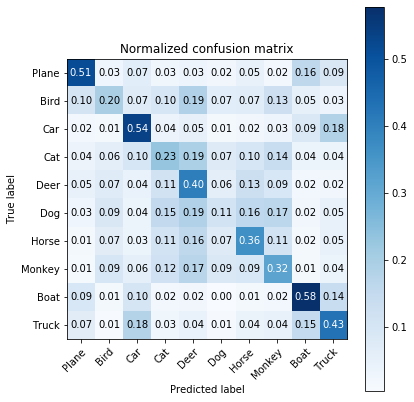

```python
test(models[0.001],test_dataloader)
```